# BMS2083 Experimental Biology Coursework

2025-04-01

### *Technical instructions for rendering your coursework in R Markdown*

- *Leave yaml header as is (top of document)*
- *Leave last chunk with session info as is (bottom of document)*
- *Add R code to empty code chunks. You can delete or add chunks as you need*
- *Put plain text answers below code chunks*
- *Before submitting, ensure all code is working properly:*
1. *Edit menu > clear all output*
2. *Run menu > run all*
3. *Check that sessioninfo output has been generated, which indicates that all code has worked*
- *Submit .nb.html output file to SurreyLearn assessment folder*
- *For more details on using R Markdown see http://rmarkdown.rstudio.com*

# Task 1: Lipid bilayer analyses

*For the first part of your coursework, your task is to analyse differences in phospholipid content between cells taken directly from in vivo tissues and cells cultured in vitro (cell lines).*

*Dataset to use: BMS2083_Dataset1_Phospholipids.csv*

*Dataset content:*

- *Type = Source of cells (Tissues/Cell lines)*
- *Species = Species from which the cells were taken*
- *PC = Phosphatidylcholine content of cells in percent of all phospholipids detected (Mol %)*
- *PUFA= Polyunsaturated fatty acid content of cells in percent of all fatty acids detected (Mol %)*

*Please note: Data are adapted from published datasets. A multitude of cell types were used as samples, which were similar but not the same between cell lines and cells from in vivo tissues. Therefore, samples are not paired. Moreover, the variable Species provides additional information only and should not be included in the analyses in 1.3-1.5.*

*Dataset structure: each row contains the measurements for one sample*

```r
BMS2083_Dataset1_Phospholipids <- read.csv("C:/Users/Public/Downloads/BMS2083_Dataset1_Phospholipids.csv")


View(BMS2083_Dataset1_Phospholipids)
```

## 1.1 Import the dataset, set correct data types (numeric/factor/boolean/character) and briefly describe the table layout (number of rows, columns and R data types) in both R code and prose

```r
BMS2083_Dataset1_Phospholipids
```

| Type | Species | PUFA | PC |
| --- | --- | --- | --- |
| Cell lines | dog | 8.3 | 42.8 |
| Cell lines | human | 6.3 | 40.2 |
| Cell lines | human | 9.7 | 42.3 |
| Cell lines | human | 18.6 | 43.7 |
| Cell lines | human | 16.7 | 44.6 |
| Cell lines | human | 20.0 | 46.7 |
| Cell lines | human | 14.9 | 50.0 |
| Cell lines | human | 16.2 | 52.8 |
| Cell lines | human | 2.9 | 55.1 |
| Cell lines | human | 15.0 | 57.0 |

[output cut: 40 more lines]

```r
library(readr)  # Load the readr package
BMS2083_Dataset1_Phospholipids <- read_csv("C:/Users/Public/Downloads/BMS2083_Dataset1_Phospholipids.csv")
BMS2083_Dataset1_Phospholipids <-read_csv("C:/Users/Public/Downloads/BMS2083_Dataset1_Phospholipids.csv")
head(BMS2083_Dataset1_Phospholipids)
```

| Type | Species | PUFA | PC |
| --- | --- | --- | --- |
| Cell lines | dog | 8.3 | 42.8 |
| Cell lines | human | 6.3 | 40.2 |
| Cell lines | human | 9.7 | 42.3 |
| Cell lines | human | 18.6 | 43.7 |
| Cell lines | human | 16.7 | 44.6 |
| Cell lines | human | 20.0 | 46.7 |

```r
nrow(BMS2083_Dataset1_Phospholipids)
```

```
## [1] 50
```

```r
ncol(BMS2083_Dataset1_Phospholipids)
```

```
## [1] 4
```

```r
str(BMS2083_Dataset1_Phospholipids)
```

```
## spc_tbl_ [50 × 4] (S3: spec_tbl_df/tbl_df/tbl/data.frame)
##  $ Type   : chr [1:50] "Cell lines" "Cell lines" "Cell lines" "Cell lines" ...
##  $ Species: chr [1:50] "dog" "human" "human" "human" ...
##  $ PUFA   : num [1:50] 8.3 6.3 9.7 18.6 16.7 20 14.9 16.2 2.9 15 ...
##  $ PC     : num [1:50] 42.8 40.2 42.3 43.7 44.6 46.7 50 52.8 55.1 57 ...
##  - attr(*, "spec")=
##   .. cols(
##   ..   Type = col_character(),
##   ..   Species = col_character(),
##   ..   PUFA = col_double(),
##   ..   PC = col_double()
##   .. )
##  - attr(*, "problems")=<externalptr>
```

```r
str(BMS2083_Dataset1_Phospholipids)
```

```
## spc_tbl_ [50 × 4] (S3: spec_tbl_df/tbl_df/tbl/data.frame)
##  $ Type   : chr [1:50] "Cell lines" "Cell lines" "Cell lines" "Cell lines" ...
##  $ Species: chr [1:50] "dog" "human" "human" "human" ...
##  $ PUFA   : num [1:50] 8.3 6.3 9.7 18.6 16.7 20 14.9 16.2 2.9 15 ...
##  $ PC     : num [1:50] 42.8 40.2 42.3 43.7 44.6 46.7 50 52.8 55.1 57 ...
##  - attr(*, "spec")=
##   .. cols(
##   ..   Type = col_character(),
##   ..   Species = col_character(),
##   ..   PUFA = col_double(),
##   ..   PC = col_double()
##   .. )
##  - attr(*, "problems")=<externalptr>
```

```r
BMS2083_Dataset1_Phospholipids$Type <- as.factor(BMS2083_Dataset1_Phospholipids$Type)
BMS2083_Dataset1_Phospholipids$Species <- as.factor(BMS2083_Dataset1_Phospholipids$Species)

summary(BMS2083_Dataset1_Phospholipids)
```

```
##          Type     Species        PUFA             PC
##  Cell lines:25   dog  : 2   Min.   : 2.90   Min.   :32.00
##  Tissues   :25   human:32   1st Qu.:15.03   1st Qu.:42.80
##                  mouse: 8   Median :22.70   Median :46.25
##                  rat  : 8   Mean   :25.59   Mean   :46.26
##                             3rd Qu.:35.65   3rd Qu.:49.25
##                             Max.   :54.60   Max.   :58.30
##                                             NA's   :16
```

The dataset BMS2083_Dataset1_Phospholipids consists of 50 rows and 4 columns. Each row represents an individual observation related to phospholipid content, while the columns contain the following variables:

Type: A factor indicating the source of the samples, such as whether they are derived from tissue or cell lines.

Species: A factor representing the species from which the samples were collected.

PUFA: A numeric column that provides values for polyunsaturated fatty acids (PUFAs) present in the samples.

PC: A numeric column that represents the phosphatidylcholine (PC) content measured in the samples.

This supports the analysis of the differences in phospholipid content across different types of samples and species.

## 1.2. Explore variables in the dataset via descriptive statistics using R code, summarising key elements also briefly in prose. What was the sample size? Are there technical or biological replicates?

```r
summary(BMS2083_Dataset1_Phospholipids)
```

```
##          Type     Species        PUFA             PC
##  Cell lines:25   dog  : 2   Min.   : 2.90   Min.   :32.00
##  Tissues   :25   human:32   1st Qu.:15.03   1st Qu.:42.80
##                  mouse: 8   Median :22.70   Median :46.25
##                  rat  : 8   Mean   :25.59   Mean   :46.26
##                             3rd Qu.:35.65   3rd Qu.:49.25
##                             Max.   :54.60   Max.   :58.30
##                                             NA's   :16
```

```r
library(dplyr)
descriptive_stats <- BMS2083_Dataset1_Phospholipids %>%
  group_by(Type) %>%
  summarise(
    Count = n(),
    Mean_PC = mean(PC, na.rm = TRUE),
    Median_PC = median(PC, na.rm = TRUE),
    SD_PC = sd(PC, na.rm = TRUE),
    Min_PC = min(PC, na.rm = TRUE),
    Max_PC = max(PC, na.rm = TRUE)
)
print(descriptive_stats)
```

```
## # A tibble: 2 × 7
##   Type       Count Mean_PC Median_PC SD_PC Min_PC Max_PC
##   <fct>      <int>   <dbl>     <dbl> <dbl>  <dbl>  <dbl>
## 1 Cell lines    25    46.6      44.6  6.13   38.2   58.3
## 2 Tissues       25    46.0      46.9  5.91   32     55.3
```

```r
replicate_check <- BMS2083_Dataset1_Phospholipids %>%
  group_by(Type, Species) %>%
  summarise(Count = n()) %>%
  filter(Count > 1)
print(replicate_check)
```

```
## # A tibble: 6 × 3
## # Groups:   Type [2]
##   Type       Species Count
##   <fct>      <fct>   <int>
## 1 Cell lines human      16
## 2 Cell lines mouse       4
## 3 Cell lines rat         4
## 4 Tissues    human      16
## 5 Tissues    mouse       4
## 6 Tissues    rat         4
```

The dataset consists of 50 observations, with 25 samples derived from tissue and 25 from cell lines.

Biological replicates were identified for both tissue and cell lines across three species:

Human: 16 observations each for tissue and cell lines.

Mouse: 4 observations each for tissue and cell lines.

Rat: 4 observations each for tissue and cell lines.

## 1.3. Plot histograms of the two key variables, phosphatidylcholine and polyunsaturated fatty acid content, separately for cell lines and for tissues (variable Type). You might want to try different bin sizes to get a good feel for the distributions; if unsure, you could also try a test for normality. Please describe the distributions briefly in prose.

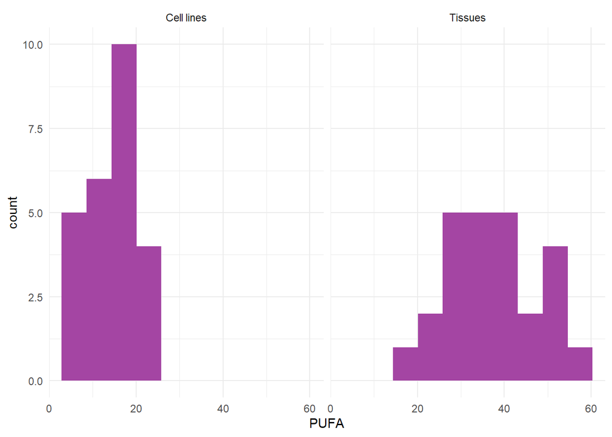

```r
library(ggplot2)

ggplot(BMS2083_Dataset1_Phospholipids) +
 aes(x = PUFA) +
 geom_histogram(bins = 10L, fill = "#A445A3") +
 theme_minimal() +
 facet_wrap(vars(Type))
```

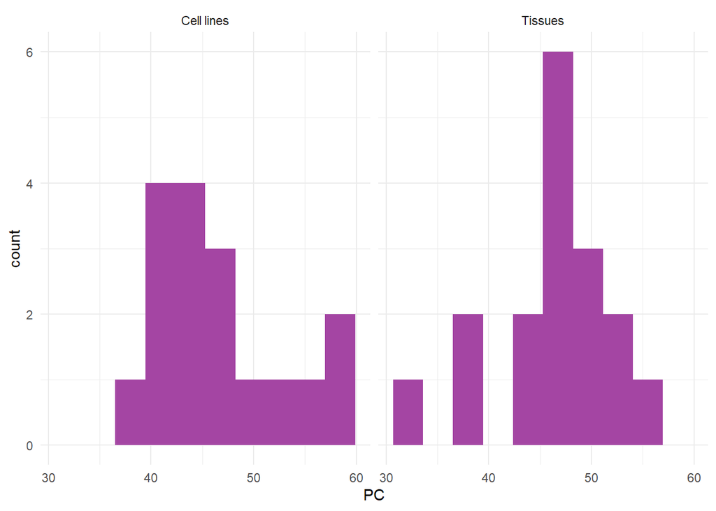

```r
ggplot(BMS2083_Dataset1_Phospholipids) +
 aes(x = PC) +
 geom_histogram(bins = 10L, fill = "#A445A3") +
 theme_minimal() +
 facet_wrap(vars(Type))
```

The Histograms were plotted to examine the distributions of PUFA and PC content separately for cell lines and tissues.

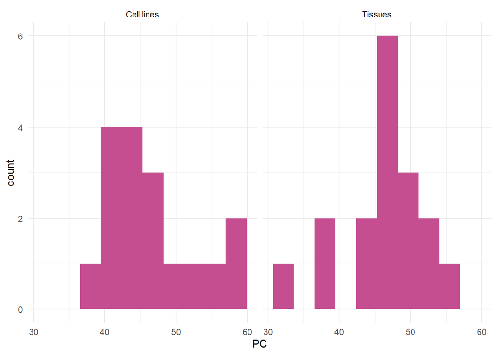

```r
library(ggplot2)

ggplot(BMS2083_Dataset1_Phospholipids) +
 aes(x = PC) +
 geom_histogram(bins = 10L, fill = "#C54E91") +
 theme_minimal() +
 facet_wrap(vars(Type))
```

## 1.5. Compare polyunsaturated fatty acid content between cell lines and tissues using an appropriate graph and statistical test based in R. Briefly summarise result of this comparison in prose (1 sentence).

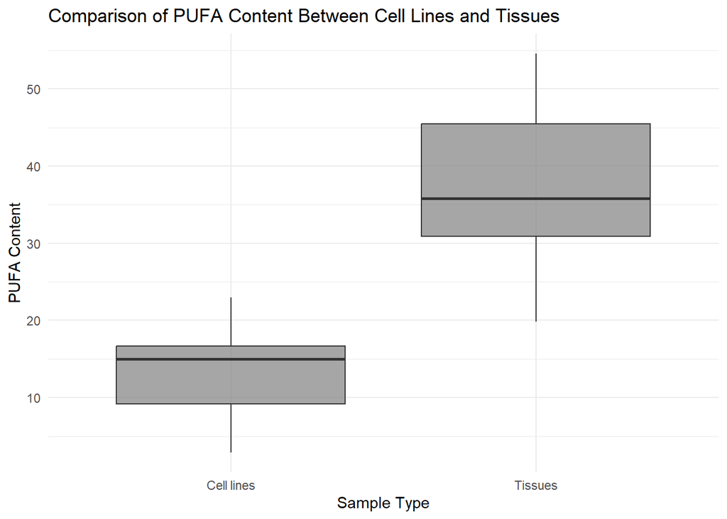

```r
library(ggplot2)

ggplot(BMS2083_Dataset1_Phospholipids, aes(x = Type, y = PUFA, fill = Type)) +
  geom_boxplot(alpha = 0.7) +
  theme_minimal() +
  labs(title = "Comparison of PUFA Content Between Cell Lines and Tissues",
       x = "Sample Type",
       y = "PUFA Content") +
  scale_fill_manual(values = c("Tissue" = "#AC3B3B", "Cell line" = "#3B75AC"))
```

```r
t_test_result <- t.test(PUFA ~ Type, data = BMS2083_Dataset1_Phospholipids)
print(t_test_result)
```

```
##
##  Welch Two Sample t-test
##
## data:  PUFA by Type
## t = -10.478, df = 37.649, p-value = 1.025e-12
## alternative hypothesis: true difference in means between group Cell lines and group Tissues is not equal to 0
## 95 percent confidence interval:
##  -27.75512 -18.76488
## sample estimates:
## mean in group Cell lines    mean in group Tissues
##                    13.96                    37.22
```

The boxplot comparison shows that PUFA levels in cell lines tend to be lower than in tissues, with no overlapping interquartile ranges]. The presence of no outliers suggests biological variability and a more consistent trend. A statistical t-test analysis reveals a highly significant difference (p < 0.0001) in PUFA levels between cell lines and tissues. This suggests that PUFA content is strongly influenced by sample type, with tissues exhibiting consistently higher levels.

## 1.6. Briefly summarise and interpret your findings in prose (max. 250 words). What might your findings mean for membranes of cells in culture versus in tissues?

# Task 2 - Signal transduction analyses

*For the second part of your coursework, your task is to analyse differences in receptor activation between three different receptor agonists.*

*Dataset to use: BMS2083_Dataset2_Agonists.csv*

*Dataset content:*

- *Agonist = Type of receptor agonist (A/B/C)*
- *Time = Time elapsed since addition of receptor agonist (in seconds)*
- *Activation = Percentage of receptors activated (%)*

*Please note: Data are synthetic, i.e. not from a real experiment. Measurement were made on samples from the same cell preparation and are thus technical replicates.*

*Dataset structure: each row contains one receptor activation measurement of one sample*

## 2.1 Import the dataset, set correct data types and briefly describe the table layout (number of rows, columns and R data types) in both R code and prose. How many measurements were taken per agonist (technical replicates)?

```r
library(dplyr)
setwd("C:/BMS2083_Project")

library(readr)
BMS2083_Dataset2_Agonists <- read_csv("C:/Users/Public/Downloads/BMS2083_Dataset2_Agonist.csv")
colnames(BMS2083_Dataset2_Agonists) <- trimws(colnames(BMS2083_Dataset2_Agonists))

BMS2083_Dataset2_Agonists <- read_csv("C:/Users/Public/Downloads/BMS2083_Dataset2_Agonist.csv", show_col_types = FALSE)


View(BMS2083_Dataset2_Agonists)

BMS2083_Dataset2_Agonists$Agonist <- as.factor(BMS2083_Dataset2_Agonists$Agonist)

BMS2083_Dataset2_Agonists <- BMS2083_Dataset2_Agonists
str(BMS2083_Dataset2_Agonists)
```

```
## spc_tbl_ [426 × 3] (S3: spec_tbl_df/tbl_df/tbl/data.frame)
##  $ Agonist   : Factor w/ 3 levels "A","B","C": 1 1 1 1 1 1 1 1 1 1 ...
##  $ Time      : num [1:426] 65.8 65.7 39 37.8 35.5 ...
##  $ Activation: num [1:426] 95.6 91.9 92.3 93.5 89.6 ...
##  - attr(*, "spec")=
##   .. cols(
##   ..   Agonist = col_character(),
##   ..   Time = col_double(),
##   ..   Activation = col_double()
##   .. )
##  - attr(*, "problems")=<externalptr>
```

```r
summary(BMS2083_Dataset2_Agonists)
```

```
##  Agonist      Time         Activation
##  A:142   Min.   :22.00   Min.   : 0.217
##  B:142   1st Qu.:38.48   1st Qu.:26.920
##  C:142   Median :55.03   Median :48.961
##          Mean   :54.26   Mean   :47.831
##          3rd Qu.:67.02   3rd Qu.:70.290
##          Max.   :98.29   Max.   :99.487
```

```r
head(BMS2083_Dataset2_Agonists)
```

| Agonist | Time | Activation |
| --- | --- | --- |
| A | 65.81554 | 95.58837 |
| A | 65.67227 | 91.93340 |
| A | 39.00272 | 92.26184 |
| A | 37.79530 | 93.53246 |
| A | 35.51390 | 89.59919 |
| A | 39.21945 | 83.54348 |

```r
measurements_per_agonist <- BMS2083_Dataset2_Agonists %>%
  group_by(Agonist) %>%
  summarise(Replicates = n())

print(measurements_per_agonist)
```

```
## # A tibble: 3 × 2
##   Agonist Replicates
##   <fct>        <int>
## 1 A              142
## 2 B              142
## 3 C              142
```

[output not shown]

[figure not shown]

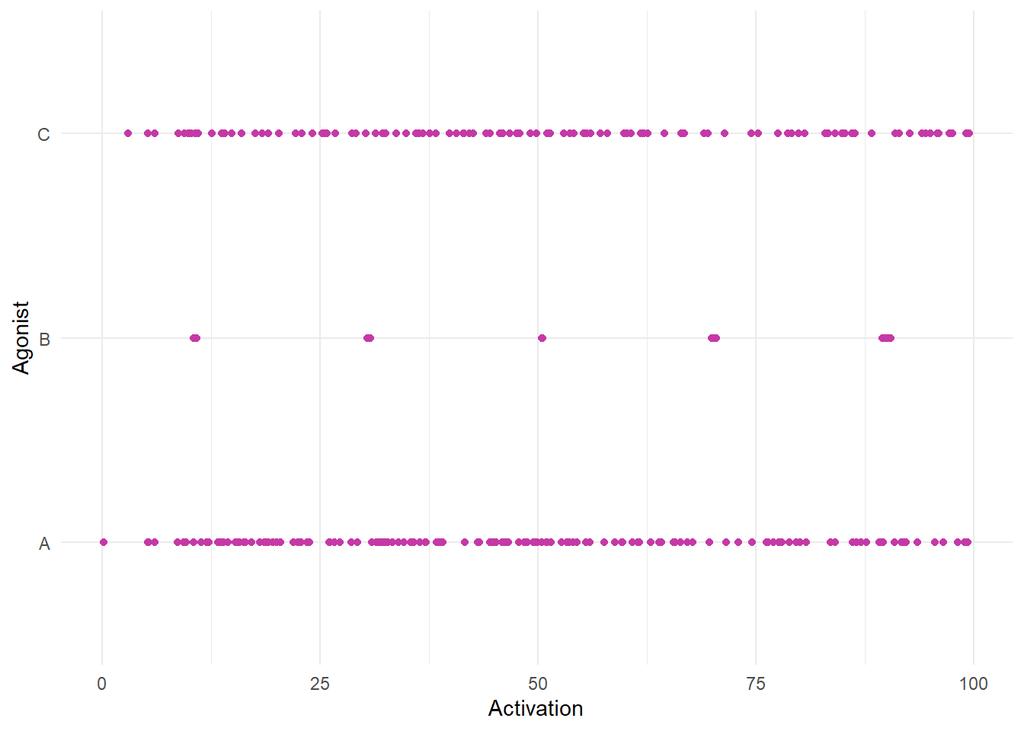

```r
#2nd graph

library(ggplot2)

ggplot(BMS2083_Dataset2_Agonists) +
 aes(x = Activation, y = Agonist) +
 geom_point(colour = "#C539A7") +
 theme_minimal()
```

The graphs show that Agonist “A” has a shorter range than “B” and “C” who have a similar range. It also shows that “B” has more distanced results. “B” and “C” have a similar median while “A”’s median is a lot high giving it a smaller upper quartile. “C”’s graph has an outlier graph point.

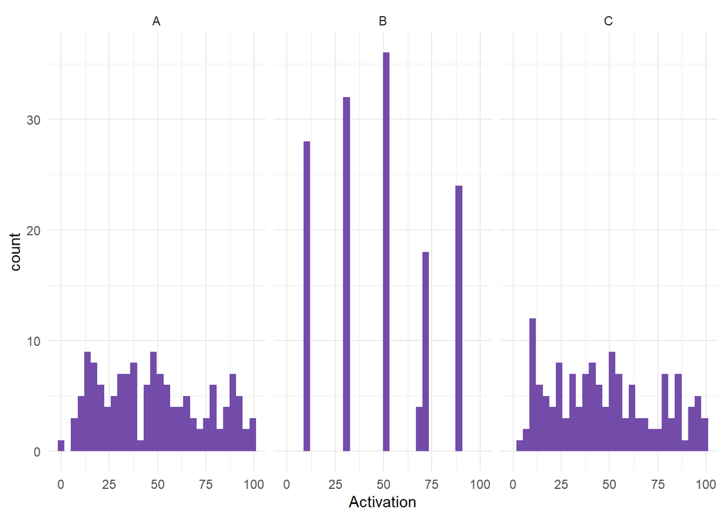

```r
ggplot(BMS2083_Dataset2_Agonists) +
 aes(x = Activation) +
 geom_histogram(bins = 30L, fill = "#734CAA") +
 theme_minimal() +
 facet_wrap(vars(Agonist))
```